# Dataset Examples

# Package ‘woolridge’

Read directly from the website:

```r
library( foreign )

dat <- read.dta( "http://fmwww.bc.edu/ec-p/data/wooldridge/meap01.dta" )

dat <- read.dta( "http://fmwww.bc.edu/ec-p/data/wooldridge/affairs.dta" )
```

R package:

```r
install.packages( "wooldridge" )
library( wooldridge )
```

## Affairs Dataset

```r
data( "affairs" )
head( affairs ) %>% pander()
```

Table continues below

| id | male | age | yrsmarr | kids | relig | educ | occup | ratemarr | naffairs |
| --- | --- | --- | --- | --- | --- | --- | --- | --- | --- |
| 4 | 1 | 37 | 10 | 0 | 3 | 18 | 7 | 4 | 0 |
| 5 | 0 | 27 | 4 | 0 | 4 | 14 | 6 | 4 | 0 |
| 6 | 1 | 27 | 1.5 | 0 | 3 | 18 | 4 | 4 | 3 |
| 11 | 0 | 32 | 15 | 1 | 1 | 12 | 1 | 4 | 0 |
| 12 | 0 | 27 | 4 | 1 | 3 | 17 | 1 | 5 | 3 |
| 16 | 1 | 57 | 15 | 1 | 5 | 18 | 6 | 5 | 0 |

| affair | vryhap | hapavg | avgmarr | unhap | vryrel | smerel | slghtrel | notrel |
| --- | --- | --- | --- | --- | --- | --- | --- | --- |
| 0 | 0 | 1 | 0 | 0 | 0 | 0 | 1 | 0 |
| 0 | 0 | 1 | 0 | 0 | 0 | 1 | 0 | 0 |
| 1 | 0 | 1 | 0 | 0 | 0 | 0 | 1 | 0 |
| 0 | 0 | 1 | 0 | 0 | 0 | 0 | 0 | 0 |
| 1 | 1 | 0 | 0 | 0 | 0 | 0 | 1 | 0 |
| 0 | 1 | 0 | 0 | 0 | 1 | 0 | 0 | 0 |

- id: identifier
- male: =1 if male
- age: in years
- yrsmarr: years married
- kids: =1 if have kids
- relig: 5 = very relig., 4 = somewhat, 3 = slightly, 2 = not at all, 1 = anti
- educ: years schooling
- occup: occupation, reverse Hollingshead scale
- ratemarr: 5 = vry hap marr, 4 = hap than avg, 3 = avg, 2 = smewht unhap, 1 = vry unhap
- naffairs: number of affairs within last year
- affair: =1 if had at least one affair
- vryhap: ratemarr == 5
- hapavg: ratemarr == 4
- avgmarr: ratemarr == 3
- unhap: ratemarr == 2
- vryrel: relig == 5
- smerel: relig == 4
- slghtrel: relig == 3
- notrel: relig == 2

## School Voucher Dataset

```r
data( 'voucher' )
head( voucher ) %>% pander()
```

Table continues below

| studyid | black | hispanic | female | appyear | mnce | select | choice |
| --- | --- | --- | --- | --- | --- | --- | --- |
| 21 | 1 | 0 | 1 | 90 | 44 | 1 | 0 |
| 26 | 1 | 0 | 0 | 90 | 46 | 1 | 1 |
| 30 | 1 | 0 | 0 | 90 | 20 | 1 | 1 |
| 31 | 1 | 0 | 1 | 90 | 36 | 1 | 1 |
| 33 | 1 | 0 | 0 | 90 | 32 | 1 | 1 |
| 39 | 1 | 0 | 1 | 90 | 76 | 1 | 0 |

Table continues below

| selectyrs | choiceyrs | mnce90 | selectyrs1 | selectyrs2 | selectyrs3 |
| --- | --- | --- | --- | --- | --- |
| 4 | 1 | NA | 0 | 0 | 0 |
| 4 | 4 | NA | 0 | 0 | 0 |
| 4 | 4 | NA | 0 | 0 | 0 |
| 4 | 4 | NA | 0 | 0 | 0 |
| 4 | 4 | NA | 0 | 0 | 0 |
| 4 | 1 | 19 | 0 | 0 | 0 |

| selectyrs4 | choiceyrs1 | choiceyrs2 | choiceyrs3 | choiceyrs4 |
| --- | --- | --- | --- | --- |
| 1 | 1 | 0 | 0 | 0 |
| 1 | 0 | 0 | 0 | 1 |
| 1 | 0 | 0 | 0 | 1 |
| 1 | 0 | 0 | 0 | 1 |
| 1 | 0 | 0 | 0 | 1 |
| 1 | 1 | 0 | 0 | 0 |

# Package ‘Ecdat’

```r
install.packages( "Ecdat" )
library( Ecdat )
```

## Star Dataset

- tmathssk total math scaled score
- treadssk total reading scaled score
- classk type of class, a factor with levels (regular,small.class,regular.with.aide)
- totexpk years of total teaching experience
- sex a factor with levels (boy,girl)
- freelunk qualified for free lunch ?
- race a factor with levels (white,black,other)
- schidkn school indicator variable

```r
data( Star )
head( Star ) %>% pander()
```

Table continues below

|  | tmathssk | treadssk | classk | totexpk | sex | freelunk |
| --- | --- | --- | --- | --- | --- | --- |
| **2** | 473 | 447 | small.class | 7 | girl | no |
| **3** | 536 | 450 | small.class | 21 | girl | no |
| **5** | 463 | 439 | regular.with.aide | 0 | boy | yes |
| **11** | 559 | 448 | regular | 16 | boy | no |
| **12** | 489 | 447 | small.class | 5 | boy | yes |
| **13** | 454 | 431 | regular | 8 | boy | yes |

|  | race | schidkn |
| --- | --- | --- |
| **2** | white | 63 |
| **3** | black | 20 |
| **5** | black | 19 |
| **11** | white | 69 |
| **12** | white | 79 |
| **13** | white | 5 |

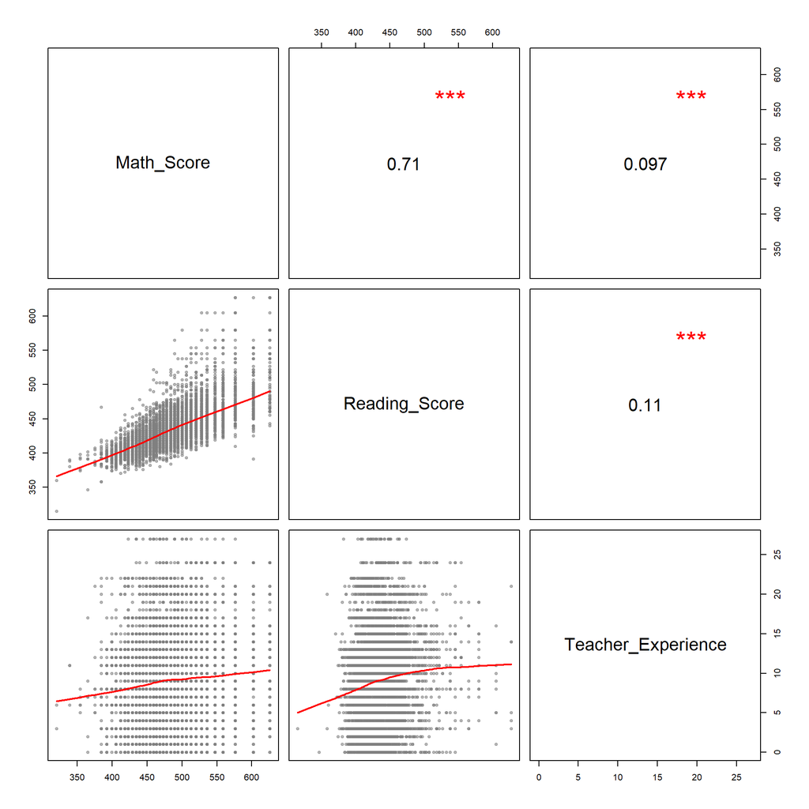

```r
dat <- dplyr::select( Star, tmathssk,treadssk, totexpk ) %>%
  dplyr::rename( Math_Score=tmathssk, Reading_Score=treadssk, Teacher_Experience=totexpk )

pairs( dat, lower.panel=panel.smooth, upper.panel=panel.cor)
```

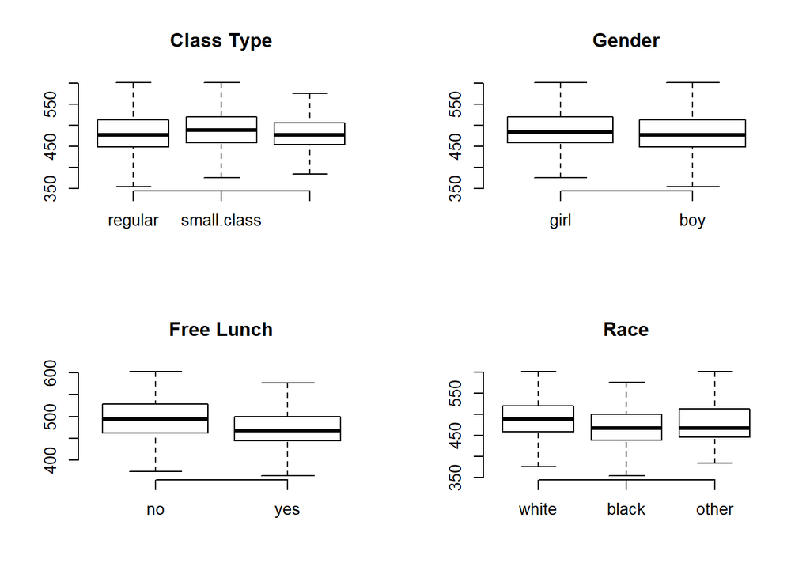

```r
par( mfrow=c(2,2) )
plot( Star$class, Star$tmathssk, frame.plot=F, outline=F, main="Class Type" )
plot( Star$sex, Star$tmathssk, frame.plot=F, outline=F, main="Gender" )
plot( Star$freelunk, Star$tmathssk, frame.plot=F, outline=F, main="Free Lunch" )
plot( Star$race, Star$tmathssk, frame.plot=F, outline=F, main="Race" )
```

[figure not shown]

```r
group.structure <- formula( Star$tmathssk ~ Star$freelunk * Star$totexpk )

boxplot( group.structure,
         las=2, frame.plot=F, outline=F, main="Age Group by Gender",
         col=c("firebrick","steelblue"), xaxt="n",
         staplewex=0, whisklty=0, ylim=c(400,600) )
```

```r
m1 <- lm( tmathssk ~ classk, data=Star )
m2 <- lm( tmathssk ~ classk + totexpk + sex + race + freelunk, data=Star )
m3 <- lm( treadssk ~ classk, data=Star )
m4 <- lm( treadssk ~ classk + totexpk + sex + race + freelunk, data=Star )

stargazer( m1, m2, m3, m4, type="html" )
```

|  | *Dependent variable:* |  |  |  |
| --- | --- | --- | --- | --- |
|  | tmathssk |  | treadssk |  |
|  | (1) | (2) | (3) | (4) |
| classksmall.class | 8.209*** | 8.200*** | 5.899*** | 5.900*** |
|  | (1.563) | (1.502) | (1.040) | (0.992) |
| classkregular.with.aide | -0.251 | -0.107 | 0.806 | 0.878 |
|  | (1.503) | (1.447) | (1.000) | (0.955) |
| totexpk |  | 0.618*** |  | 0.490*** |
|  |  | (0.106) |  | (0.070) |
| sexboy |  | -7.872*** |  | -6.135*** |
|  |  | (1.209) |  | (0.798) |
| raceblack |  | -7.746*** |  | -3.799*** |
|  |  | (1.454) |  | (0.960) |
| raceother |  | -14.486 |  | -1.870 |
|  |  | (8.841) |  | (5.837) |
| freelunkyes |  | -19.553*** |  | -14.852*** |
|  |  | (1.355) |  | (0.894) |
| Constant | 483.261*** | 493.512*** | 434.681*** | 441.649*** |
|  | (1.065) | (1.699) | (0.708) | (1.122) |
| Observations | 5,748 | 5,748 | 5,748 | 5,748 |
| R<sup>2</sup> | 0.006 | 0.083 | 0.006 | 0.097 |
| Adjusted R<sup>2</sup> | 0.006 | 0.082 | 0.006 | 0.096 |
| Residual Std. Error | 47.626 (df = 5745) | 45.765 (df = 5740) | 31.676 (df = 5745) | 30.214 (df = 5740) |
| F Statistic | 18.553*** (df = 2; 5745) | 74.563*** (df = 7; 5740) | 18.538*** (df = 2; 5745) | 87.895*** (df = 7; 5740) |
| *Note:* | p<0.1; p<0.05; p<0.01 |  |  |  |

## Dataset ‘Treatment’

```r
data( 'Treatment' )
head( Treatment ) %>% pander()
```

| treat | age | educ | ethn | married | re74 | re75 | re78 | u74 | u75 |
| --- | --- | --- | --- | --- | --- | --- | --- | --- | --- |
| TRUE | 37 | 11 | black | TRUE | 0 | 0 | 9930 | TRUE | TRUE |
| TRUE | 30 | 12 | black | FALSE | 0 | 0 | 24910 | TRUE | TRUE |
| TRUE | 27 | 11 | black | FALSE | 0 | 0 | 7506 | TRUE | TRUE |
| TRUE | 33 | 8 | black | FALSE | 0 | 0 | 289.8 | TRUE | TRUE |
| TRUE | 22 | 9 | black | FALSE | 0 | 0 | 4056 | TRUE | TRUE |
| TRUE | 23 | 12 | black | FALSE | 0 | 0 | 0 | TRUE | TRUE |